# Создание графиков взвешенной локальной регрессии, температур и осадков по всем годам участка Малая Минуса

Ильин Виктор

1 июня 2016 г

#### Чтение данных из датасета участка Малая Минуса и климатических данных участка Малая Минуса

- Работаем с метеоданными http://aisori.meteo.ru/ClimateR в [R]
- Конвертируем данные метеостанции 29866 53.42N 91.42E по температуре для работы в data.frame [R]
- Удаляем качество замера
- Присваиваем столбцам наименования
- Разделяем по разным таблицам метеостанцию Minusinsk.cli и Hakasskaja.cli

Для отображения погоды в с.Малая Минуса были использованы данные, полученные с метеостанции №1498693 “Minusinsk”, которая находится на расстоянии 7.08 км от географических координат территории 0.6 км восточнее с.Малая Минуса. Учитываем, что отдаленность метеостанции от фактического местоположения объекта влияет на точность и объективность прогноза погоды.

- Выводим структуру таблицы с климатикой
- Выводим описательную статистику
- Обычная запись (в координатах температура—время)

```
## 'data.frame':    18263 obs. of  8 variables:
##  $ Station: int  29866 29866 29866 29866 29866 29866 29866 29866 29866 29866 ...
##  $ Year   : int  1964 1964 1964 1964 1964 1964 1964 1964 1964 1964 ...
##  $ Month  : int  1 1 1 1 1 1 1 1 1 1 ...
##  $ Day    : int  1 2 3 4 5 6 7 8 9 10 ...
##  $ TMIN   : num  -23.3 -19.7 -26.1 -17.8 -5.5 -8.2 -14.4 -17.8 -17.3 -23.7 ...
##  $ TMEAN  : num  -18.5 -17 -20 -9.6 -3.6 -6.5 -11.5 -11.8 -11.3 -17.5 ...
##  $ TMAX   : num  -13.9 -12.2 -15.2 -3.1 -0.6 -2.6 -6.6 -5.2 -2.6 -13.2 ...
##  $ PRECIP : num  0 0.2 0.1 0 0 0 0 0 0 0 ...
```

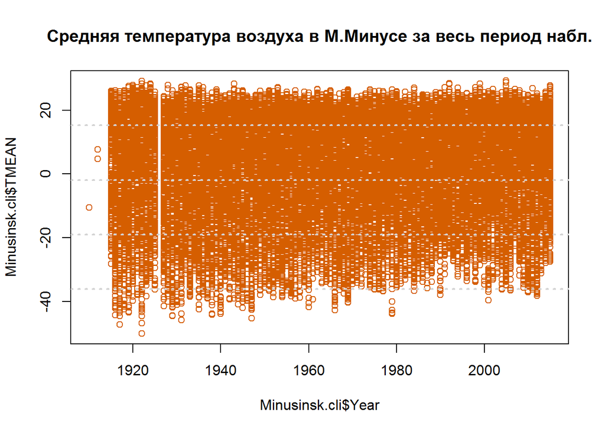

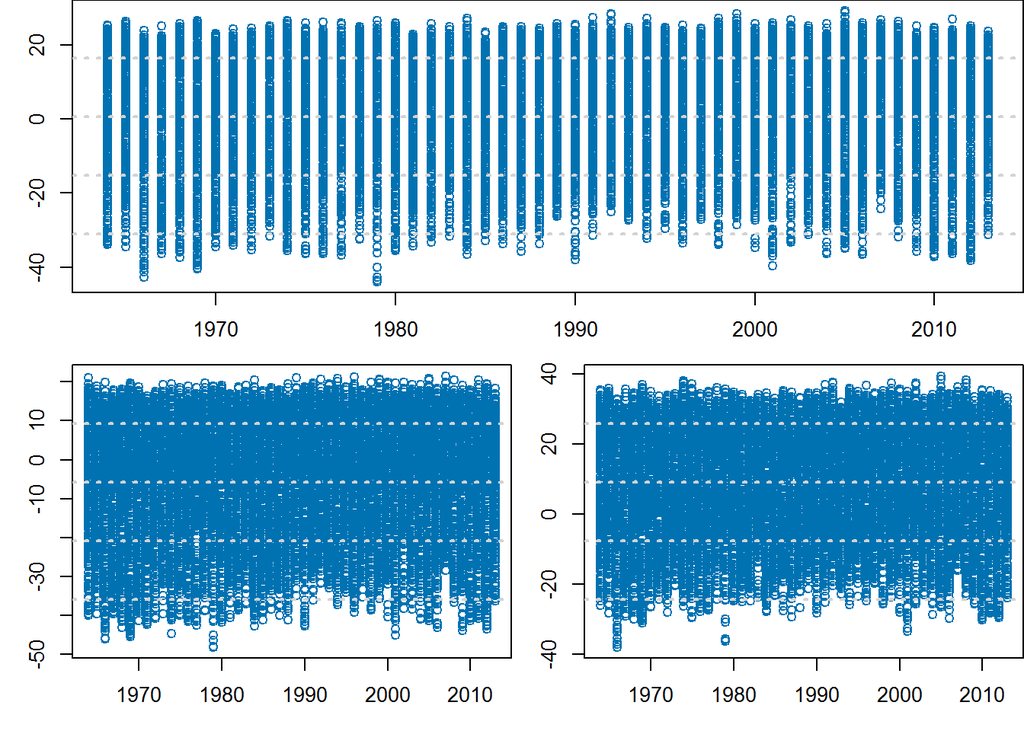

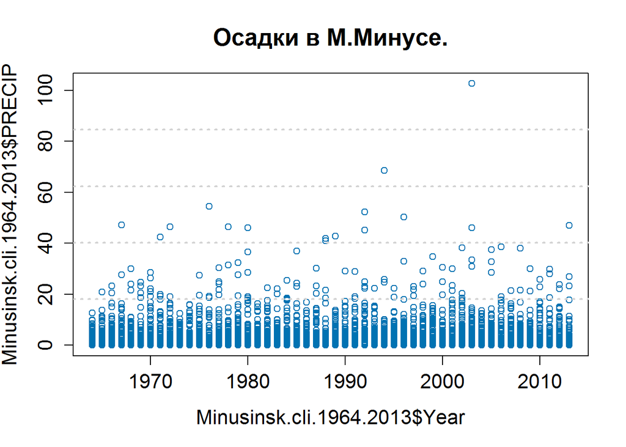

```
##       TMIN             TMEAN              TMAX             PRECIP
##  Min.   :-48.200   Min.   :-43.900   Min.   :-38.000   Min.   :  0.0000
##  1st Qu.:-15.100   1st Qu.: -9.200   1st Qu.: -3.100   1st Qu.:  0.0000
##  Median : -2.200   Median :  3.400   Median :  9.700   Median :  0.0000
##  Mean   : -4.532   Mean   :  1.599   Mean   :  8.597   Mean   :  0.9702
##  3rd Qu.:  7.700   3rd Qu.: 14.200   3rd Qu.: 21.800   3rd Qu.:  0.4000
##  Max.   : 21.500   Max.   : 29.200   Max.   : 39.300   Max.   :102.6000
##                                                        NA's   :3
```

#### Диаграммы размахов, или “ящики с усами” (англ. box-whisker plots)

В R при построении диаграмм размахов используются устойчивые (робастные) оценки центральной тенденции (медиана) и разброса (интерквартильный размах, ИКР).

- Верхний “ус” простирается от верхней границы “ящика” до наибольшего выборочного значения, находящегося в пределах расстояния 1.5 х ИКР от этой границы.
- Аналогично, нижний “ус” простирается от нижней границы “ящика” до наименьшего выборочного значения, находящегося в пределах расстояния 1.5 х ИКР от этой границы.
- Наблюдения, находящиеся за пределами “усов”, потенциально могут быть выбросами.

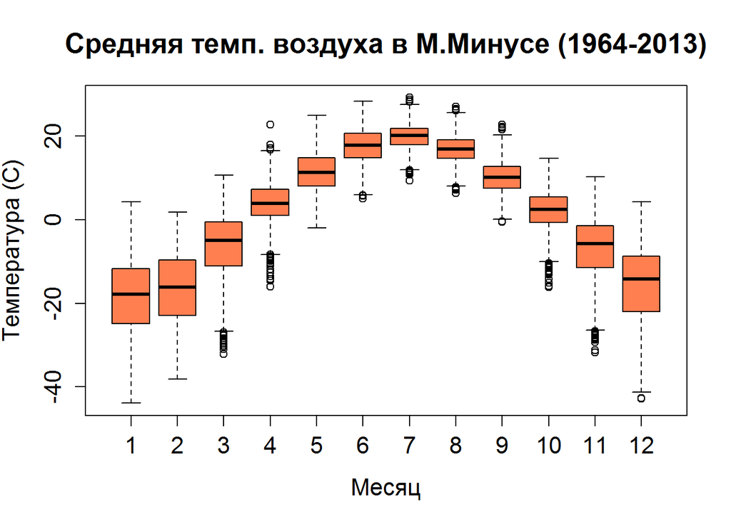

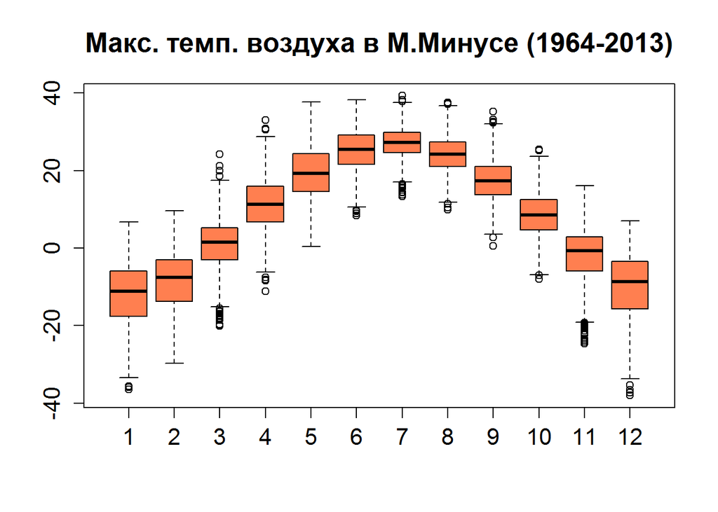

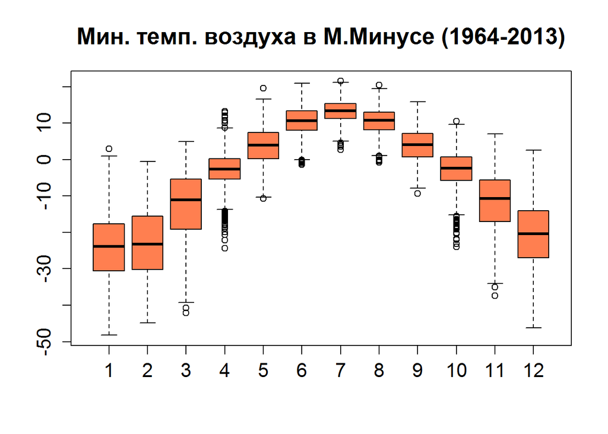

#### Стандартизированные трахеидограммы пяти (5) деревьев и сплошная линия взвешенной локальной регрессии + графическое представление climate-graph

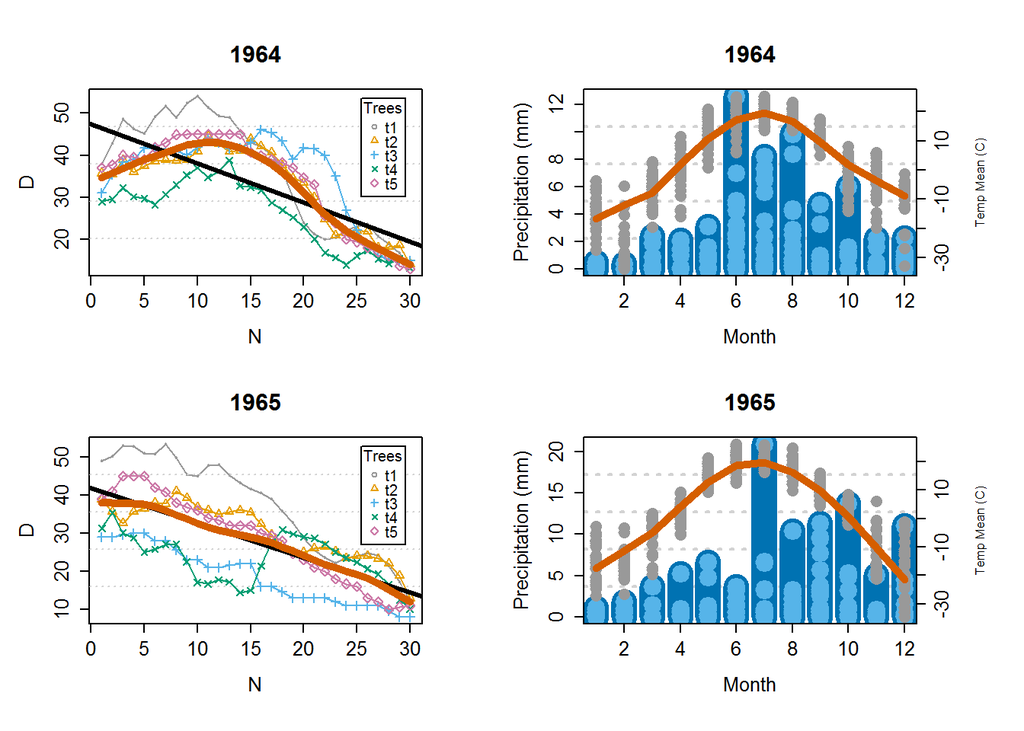

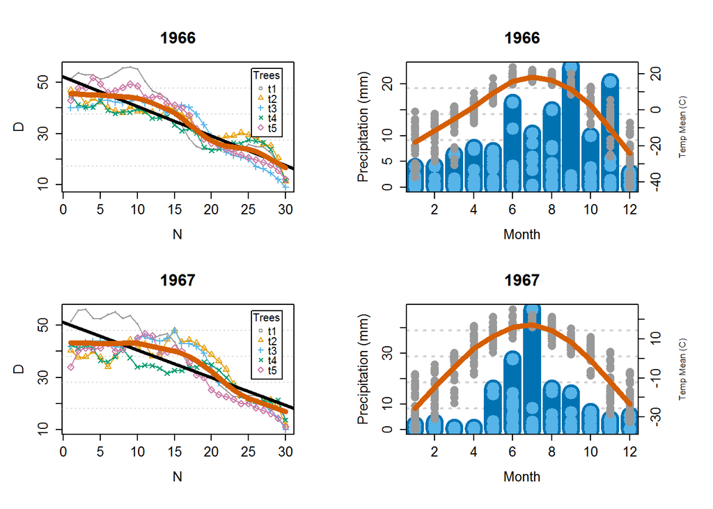

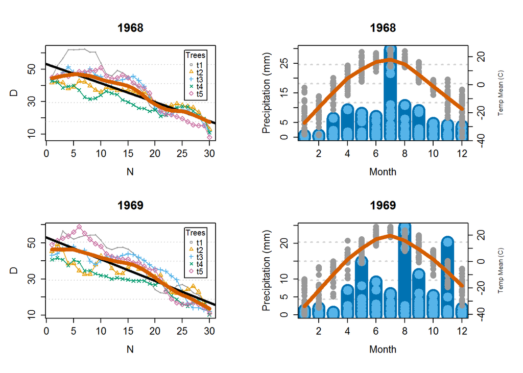

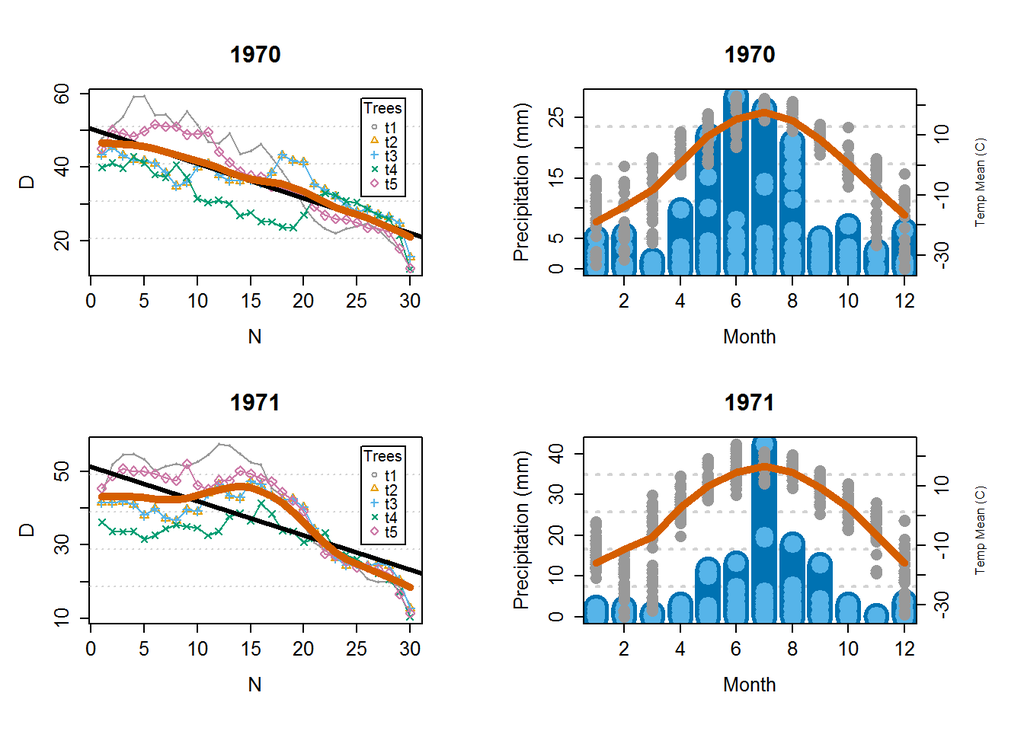

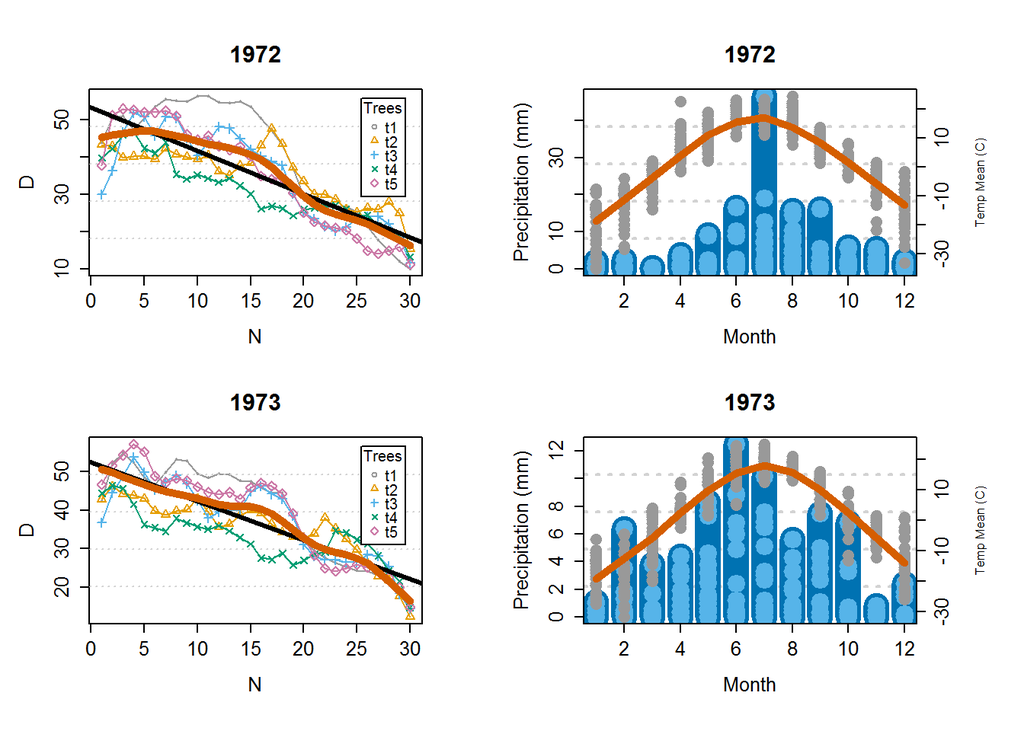

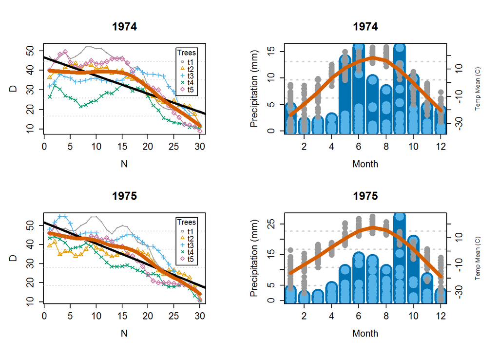

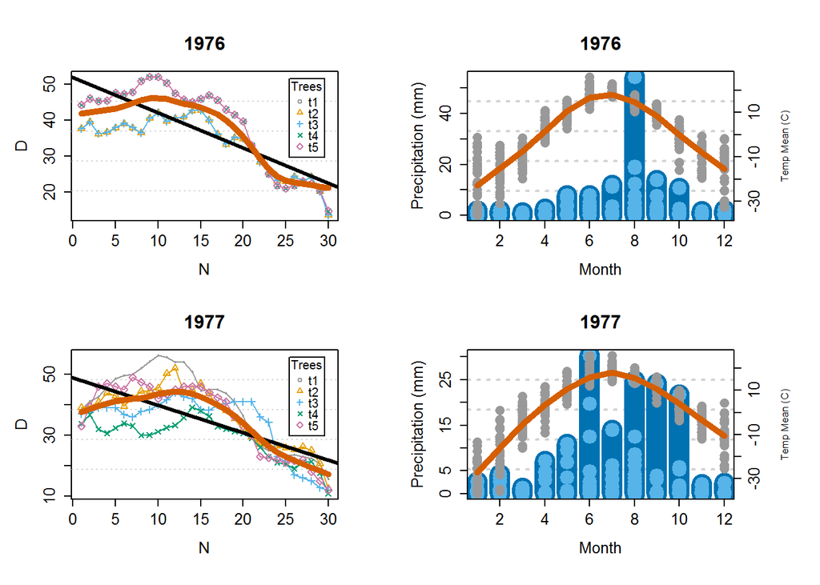

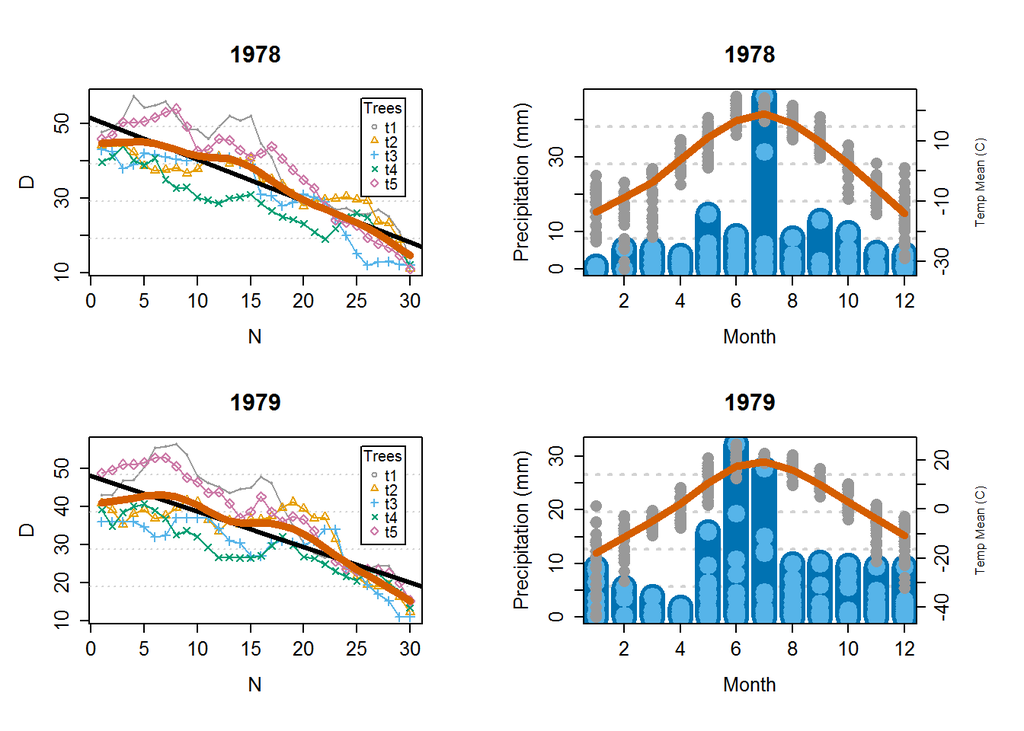

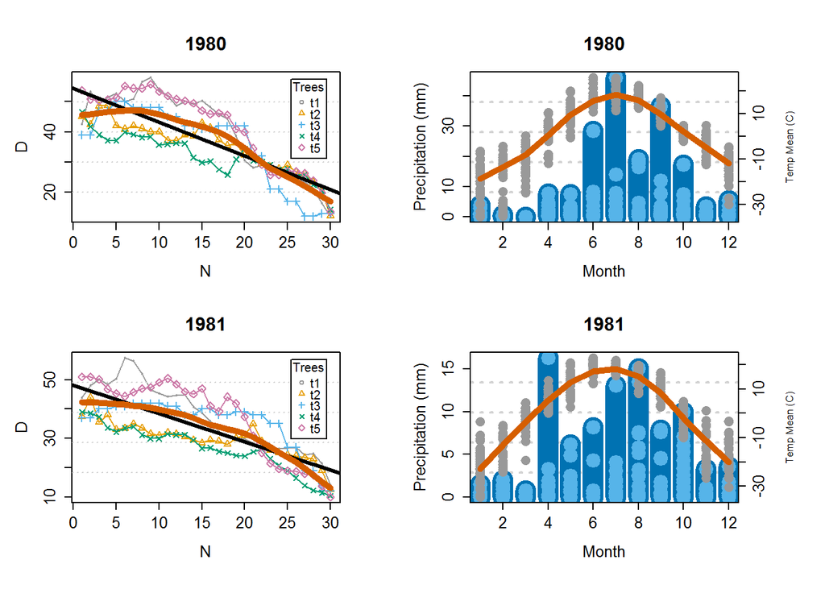

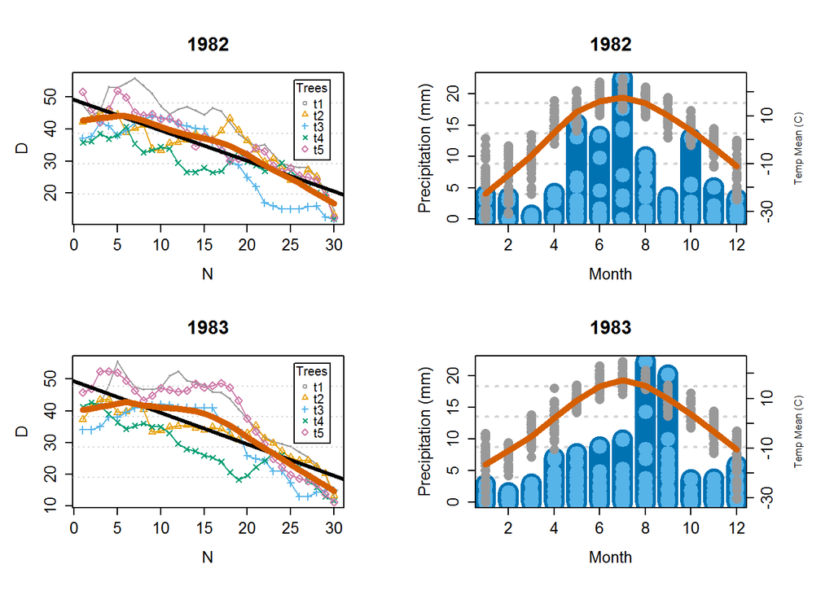

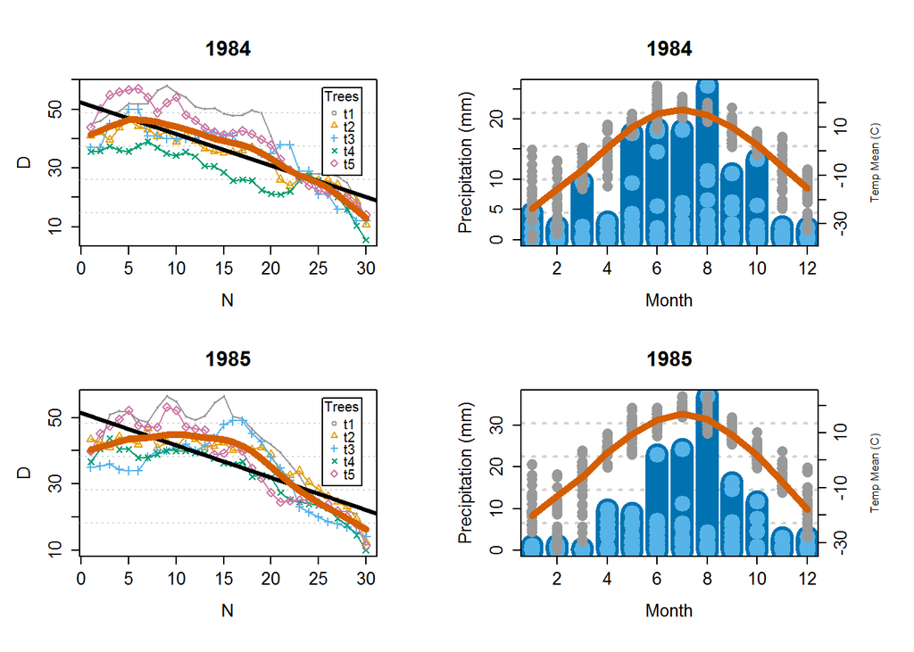

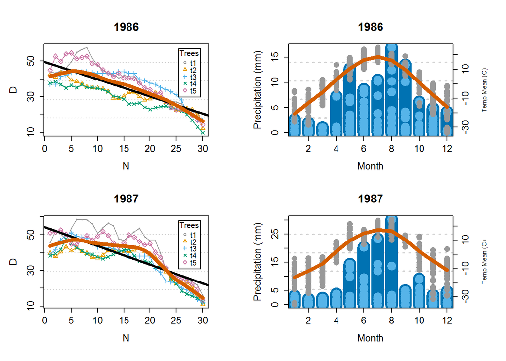

[13 more figures not shown]